# Labs 7 - Quantum Pattern Recognition

### State Phi |0->

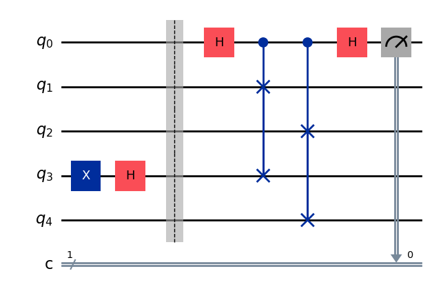

```python
qc = swap_test_circuit(prepare_psi_00, prepare_phi_0minus)
qc.draw("mpl")
```

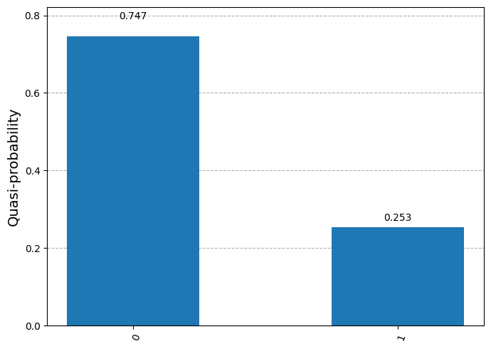

```python
backend = Aer.get_backend("qasm_simulator")
shots = 2048
transpiled_qc = transpile(qc, backend, optimization_level=3)
job = backend.run(transpiled_qc, shots=shots)
counts = job.result().get_counts()
plot_distribution(counts)
```

```python
p0, fid, over = calculate_results(counts)
results["State"].append("0-")
results["P(0)"].append(p0)
results["Fidelity"].append(fid)
results["Overlap"].append(over)
print(f"P(0): {p0:.5f}, Fidelity: {fid:.5f}, Overlap: {over:.5f}")
```

```
P(0): 0.74658, Fidelity: 0.49316, Overlap: 0.70226
```

### State Phi |-1>

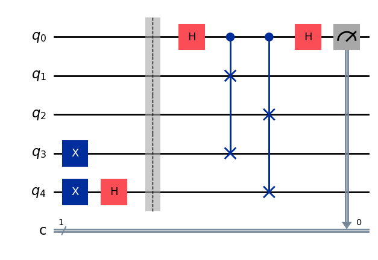

```python
qc = swap_test_circuit(prepare_psi_00, prepare_phi_minus1)
qc.draw("mpl")
```

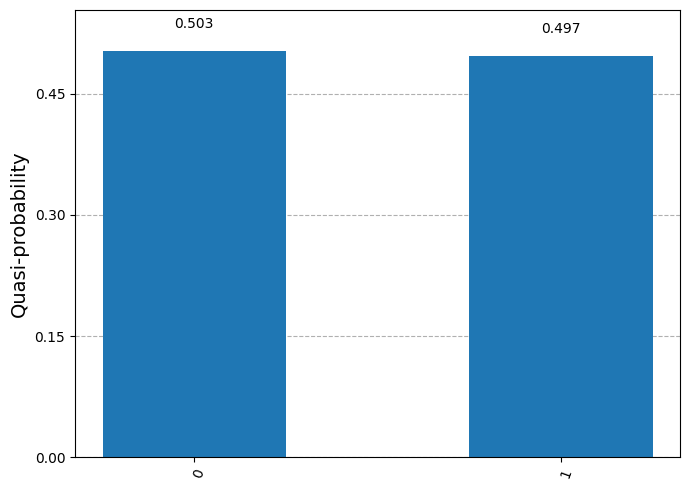

```python
backend = Aer.get_backend("qasm_simulator")
shots = 2048
transpiled_qc = transpile(qc, backend, optimization_level=3)
job = backend.run(transpiled_qc, shots=shots)
counts = job.result().get_counts()
plot_distribution(counts)
```

```python
p0, fid, over = calculate_results(counts)
results["State"].append("-1")
results["P(0)"].append(p0)
results["Fidelity"].append(fid)
results["Overlap"].append(over)
print(f"P(0): {p0:.5f}, Fidelity: {fid:.5f}, Overlap: {over:.5f}")
```

```
P(0): 0.50342, Fidelity: 0.00684, Overlap: 0.08268
```

### State Phi |-0>

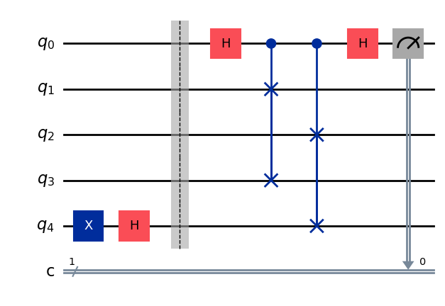

```python
qc = swap_test_circuit(prepare_psi_00, prepare_phi_minus0)
qc.draw("mpl")
```

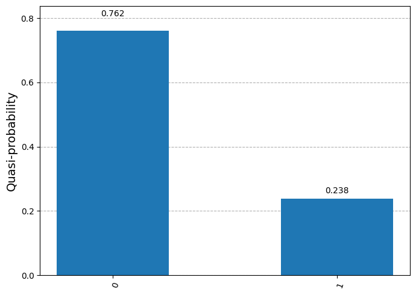

```python
backend = Aer.get_backend("qasm_simulator")
shots = 2048
transpiled_qc = transpile(qc, backend, optimization_level=3)
job = backend.run(transpiled_qc, shots=shots)
counts = job.result().get_counts()
plot_distribution(counts)
```

```python
p0, fid, over = calculate_results(counts)
results["State"].append("-0")
results["P(0)"].append(p0)
results["Fidelity"].append(fid)
results["Overlap"].append(over)
print(f"P(0): {p0:.5f}, Fidelity: {fid:.5f}, Overlap: {over:.5f}")
```

```
P(0): 0.76172, Fidelity: 0.52344, Overlap: 0.72349
```

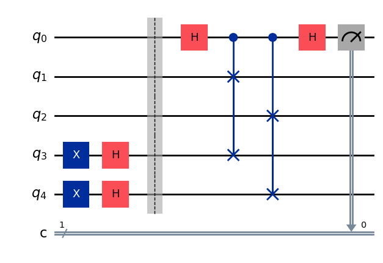

```python
qc = swap_test_circuit(prepare_psi_00, prepare_phi_1minus)
qc.draw("mpl")
```

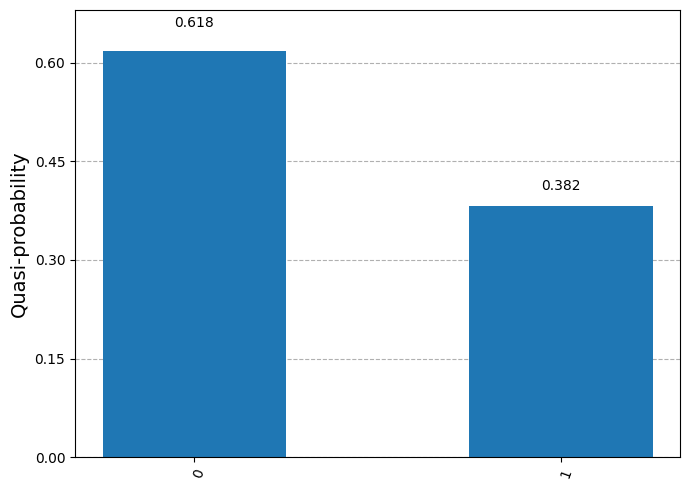

```python
backend = Aer.get_backend("qasm_simulator")
shots = 2048
transpiled_qc = transpile(qc, backend, optimization_level=3)
job = backend.run(transpiled_qc, shots=shots)
counts = job.result().get_counts()
plot_distribution(counts)
```

```python
p0, fid, over = calculate_results(counts)
results["State"].append("1-")
results["P(0)"].append(p0)
results["Fidelity"].append(fid)
results["Overlap"].append(over)
print(f"P(0): {p0:.5f}, Fidelity: {fid:.5f}, Overlap: {over:.5f}")
```

```
P(0): 0.61816, Fidelity: 0.23633, Overlap: 0.48614
```

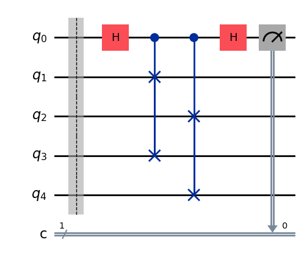

```python
qc = swap_test_circuit(prepare_psi_00, prepare_phi_minusminus)
qc.draw("mpl")
```

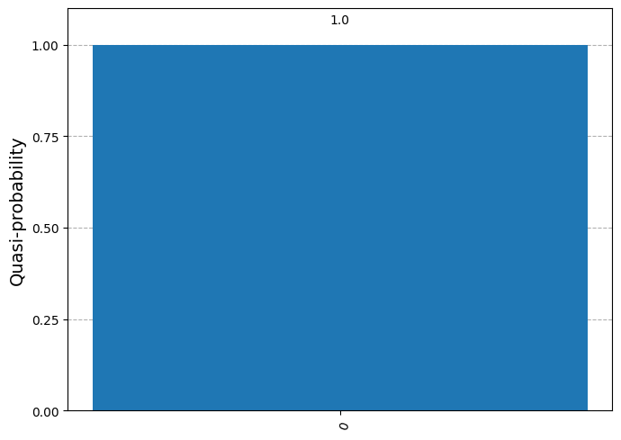

```python
backend = Aer.get_backend("qasm_simulator")
shots = 2048
transpiled_qc = transpile(qc, backend, optimization_level=3)
job = backend.run(transpiled_qc, shots=shots)
counts = job.result().get_counts()
plot_distribution(counts)
```

```python
p0, fid, over = calculate_results(counts)
results["State"].append("--")
results["P(0)"].append(p0)
results["Fidelity"].append(fid)
results["Overlap"].append(over)
print(f"P(0): {p0:.5f}, Fidelity: {fid:.5f}, Overlap: {over:.5f}")
```

```
P(0): 1.00000, Fidelity: 1.00000, Overlap: 1.00000
```

### State Phi |++>

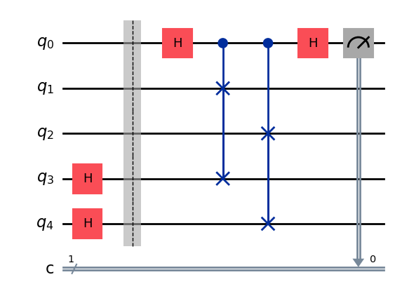

```python
qc = swap_test_circuit(prepare_psi_00, prepare_phi_plusplus)
qc.draw("mpl")
```

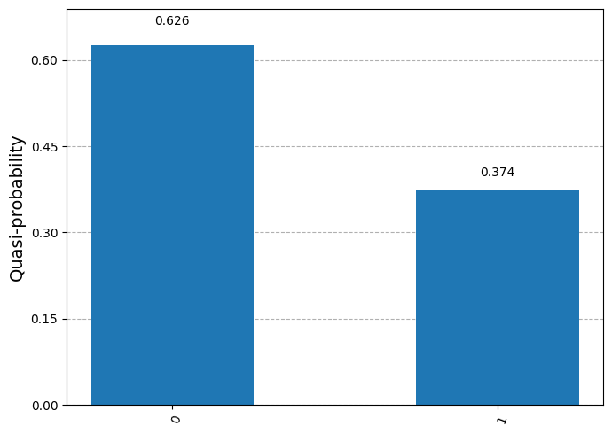

```python
backend = Aer.get_backend("qasm_simulator")
shots = 2048
transpiled_qc = transpile(qc, backend, optimization_level=3)
job = backend.run(transpiled_qc, shots=shots)
counts = job.result().get_counts()
plot_distribution(counts)
```

```python
p0, fid, over = calculate_results(counts)
results["State"].append("++")
results["P(0)"].append(p0)
results["Fidelity"].append(fid)
results["Overlap"].append(over)
print(f"P(0): {p0:.5f}, Fidelity: {fid:.5f}, Overlap: {over:.5f}")
```

```
P(0): 0.62646, Fidelity: 0.25293, Overlap: 0.50292
```

### State Phi |01>

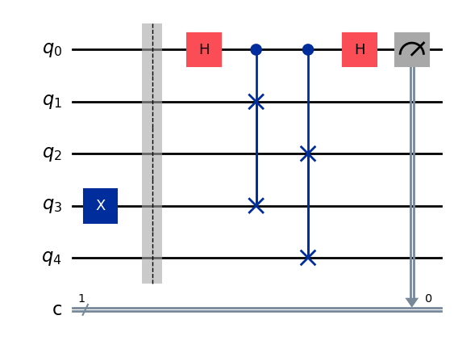

```python
qc = swap_test_circuit(prepare_psi_00, prepare_phi_01)
qc.draw("mpl")
```

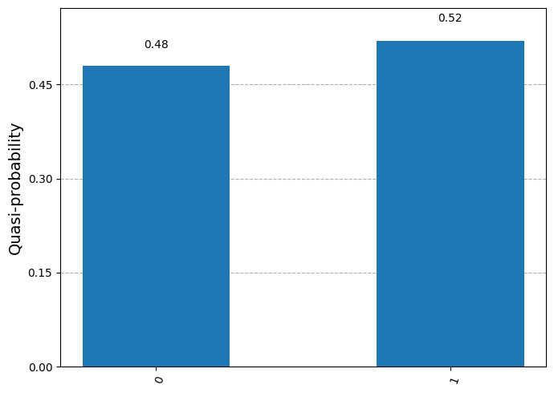

```python
backend = Aer.get_backend("qasm_simulator")
shots = 2048
transpiled_qc = transpile(qc, backend, optimization_level=3)
job = backend.run(transpiled_qc, shots=shots)
counts = job.result().get_counts()
plot_distribution(counts)
```

```python
p0, fid, over = calculate_results(counts)
results["State"].append("01")
results["P(0)"].append(p0)
results["Fidelity"].append(fid)
results["Overlap"].append(over)
print(f"P(0): {p0:.5f}, Fidelity: {fid:.5f}, Overlap: {over:.5f}")
```

```
P(0): 0.47998, Fidelity: -0.04004, Overlap: 0.00000
```

### State Phi |+1>

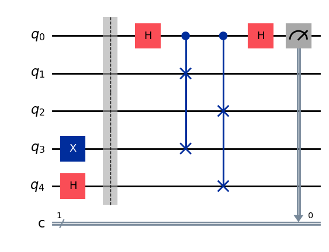

```python
qc = swap_test_circuit(prepare_psi_00, prepare_phi_plus1)
qc.draw("mpl")
```

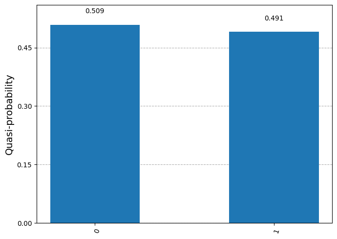

```python
backend = Aer.get_backend("qasm_simulator")
shots = 2048
transpiled_qc = transpile(qc, backend, optimization_level=3)
job = backend.run(transpiled_qc, shots=shots)
counts = job.result().get_counts()
plot_distribution(counts)
```

```python
p0, fid, over = calculate_results(counts)
results["State"].append("+1")
results["P(0)"].append(p0)
results["Fidelity"].append(fid)
results["Overlap"].append(over)
print(f"P(0): {p0:.5f}, Fidelity: {fid:.5f}, Overlap: {over:.5f}")
```

```
P(0): 0.50879, Fidelity: 0.01758, Overlap: 0.13258
```

### State Phi |1+>

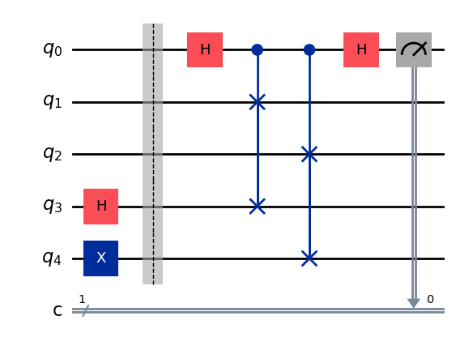

```python
qc = swap_test_circuit(prepare_psi_00, prepare_phi_1plus)
qc.draw("mpl")
```

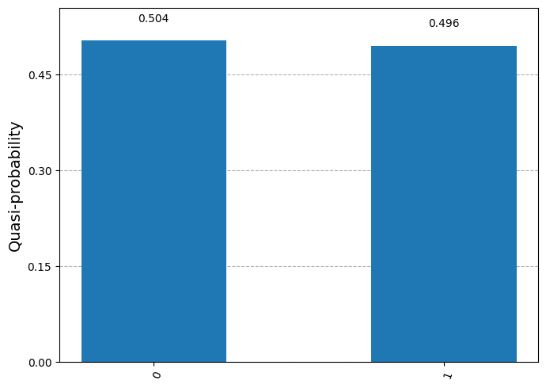

```python
backend = Aer.get_backend("qasm_simulator")
shots = 2048
transpiled_qc = transpile(qc, backend, optimization_level=3)
job = backend.run(transpiled_qc, shots=shots)
counts = job.result().get_counts()
plot_distribution(counts)
```

```python
p0, fid, over = calculate_results(counts)
results["State"].append("1+")
results["P(0)"].append(p0)
results["Fidelity"].append(fid)
results["Overlap"].append(over)
print(f"P(0): {p0:.5f}, Fidelity: {fid:.5f}, Overlap: {over:.5f}")
```

```
P(0): 0.50439, Fidelity: 0.00879, Overlap: 0.09375
```

### State Phi |0+>

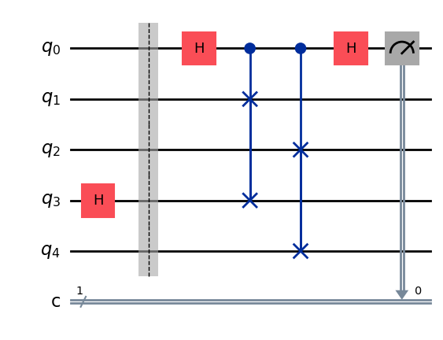

```python
qc = swap_test_circuit(prepare_psi_00, prepare_phi_0plus)
qc.draw("mpl")
```

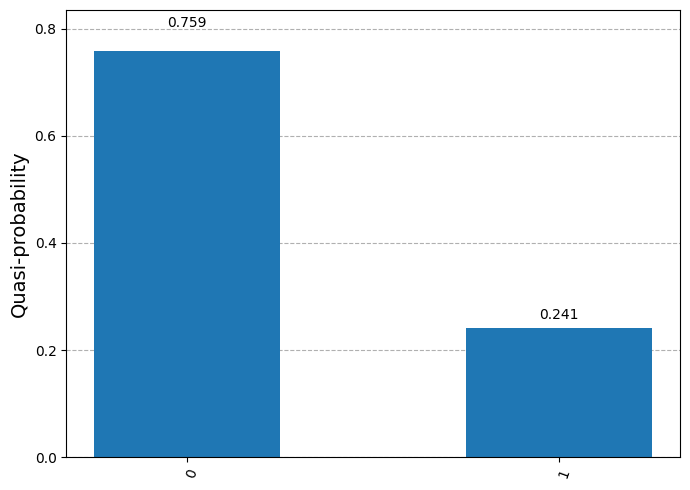

```python
backend = Aer.get_backend("qasm_simulator")
shots = 2048
transpiled_qc = transpile(qc, backend, optimization_level=3)
job = backend.run(transpiled_qc, shots=shots)
counts = job.result().get_counts()
plot_distribution(counts)
```

```python
p0, fid, over = calculate_results(counts)
results["State"].append("0+")
results["P(0)"].append(p0)
results["Fidelity"].append(fid)
results["Overlap"].append(over)
print(f"P(0): {p0:.5f}, Fidelity: {fid:.5f}, Overlap: {over:.5f}")
```

```
P(0): 0.75879, Fidelity: 0.51758, Overlap: 0.71943
```

### State Phi |00>

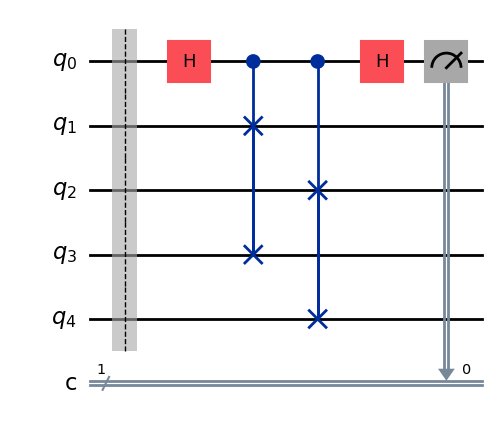

```python
qc = swap_test_circuit(prepare_psi_00, prepare_psi_00)
qc.draw("mpl")
```

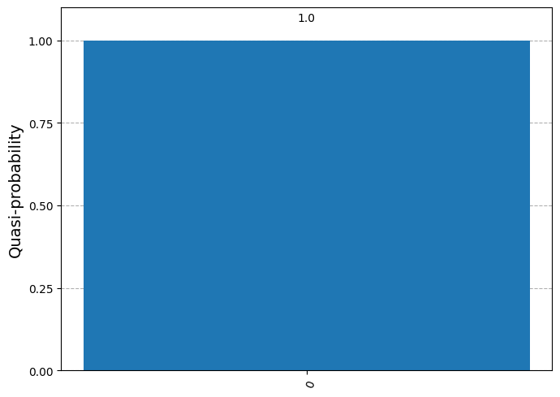

```python
backend = Aer.get_backend("qasm_simulator")
shots = 2048
transpiled_qc = transpile(qc, backend, optimization_level=3)
job = backend.run(transpiled_qc, shots=shots)
counts = job.result().get_counts()
plot_distribution(counts)
```

```python
p0, fid, over = calculate_results(counts)
results["State"].append("00")
results["P(0)"].append(p0)
results["Fidelity"].append(fid)
results["Overlap"].append(over)
print(f"P(0): {p0:.5f}, Fidelity: {fid:.5f}, Overlap: {over:.5f}")
```

```
P(0): 1.00000, Fidelity: 1.00000, Overlap: 1.00000
```

### State Phi |+->

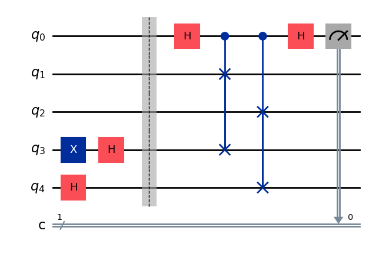

```python
qc = swap_test_circuit(prepare_psi_00, prepare_phi_plusminus)
qc.draw("mpl")
```

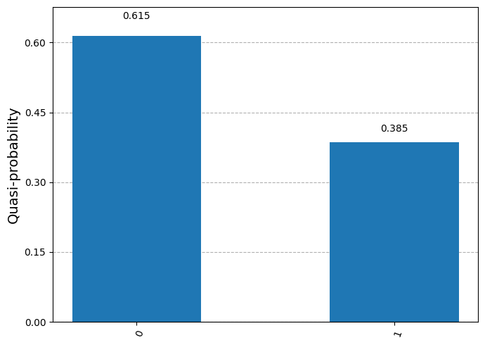

```python
backend = Aer.get_backend("qasm_simulator")
shots = 2048
transpiled_qc = transpile(qc, backend, optimization_level=3)
job = backend.run(transpiled_qc, shots=shots)
counts = job.result().get_counts()
plot_distribution(counts)
```

```python
p0, fid, over = calculate_results(counts)
results["State"].append("+-")
results["P(0)"].append(p0)
results["Fidelity"].append(fid)
results["Overlap"].append(over)
print(f"P(0): {p0:.5f}, Fidelity: {fid:.5f}, Overlap: {over:.5f}")
```

```
P(0): 0.61475, Fidelity: 0.22949, Overlap: 0.47905
```

### State Phi |11>

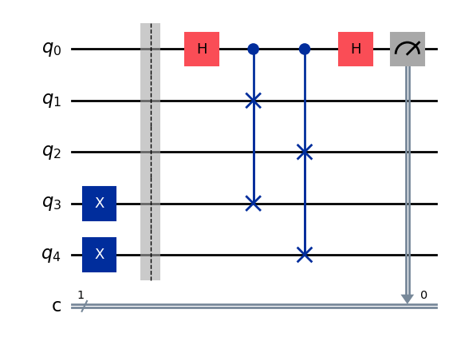

```python
qc = swap_test_circuit(prepare_psi_00, prepare_phi_11)
qc.draw("mpl")
```

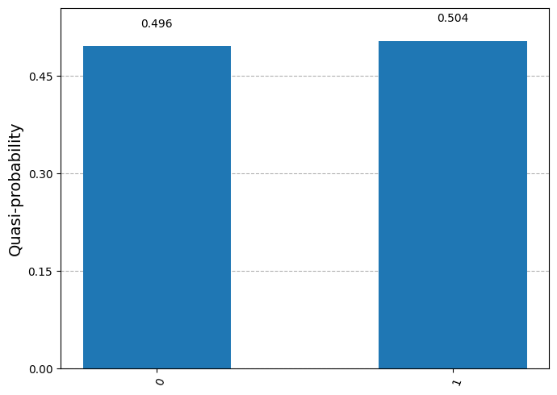

```python
backend = Aer.get_backend("qasm_simulator")
shots = 2048
transpiled_qc = transpile(qc, backend, optimization_level=3)
job = backend.run(transpiled_qc, shots=shots)
counts = job.result().get_counts()
plot_distribution(counts)
```

```python
p0, fid, over = calculate_results(counts)
results["State"].append("11")
results["P(0)"].append(p0)
results["Fidelity"].append(fid)
results["Overlap"].append(over)
print(f"P(0): {p0:.5f}, Fidelity: {fid:.5f}, Overlap: {over:.5f}")
```

```
P(0): 0.49609, Fidelity: -0.00781, Overlap: 0.00000
```

### State Phi |-+>

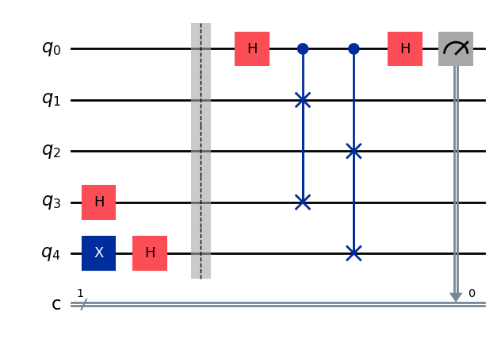

```python
qc = swap_test_circuit(prepare_psi_00, prepare_phi_minusplus)
qc.draw("mpl")
```

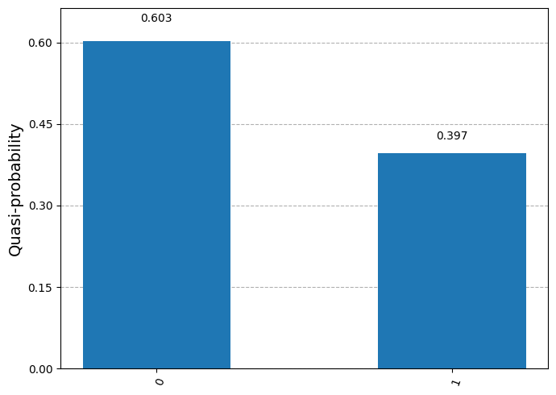

```python
backend = Aer.get_backend("qasm_simulator")
shots = 2048
transpiled_qc = transpile(qc, backend, optimization_level=3)
job = backend.run(transpiled_qc, shots=shots)
counts = job.result().get_counts()
plot_distribution(counts)
```

```python
p0, fid, over = calculate_results(counts)
results["State"].append("-+")
results["P(0)"].append(p0)
results["Fidelity"].append(fid)
results["Overlap"].append(over)
print(f"P(0): {p0:.5f}, Fidelity: {fid:.5f}, Overlap: {over:.5f}")
```

```
P(0): 0.60303, Fidelity: 0.20605, Overlap: 0.45393
```

### State Phi |10>

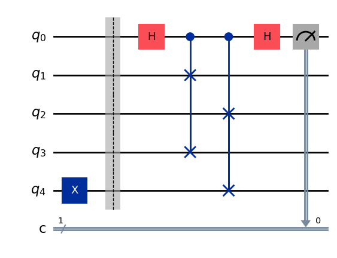

```python
qc = swap_test_circuit(prepare_psi_00, prepare_phi_10)
qc.draw("mpl")
```

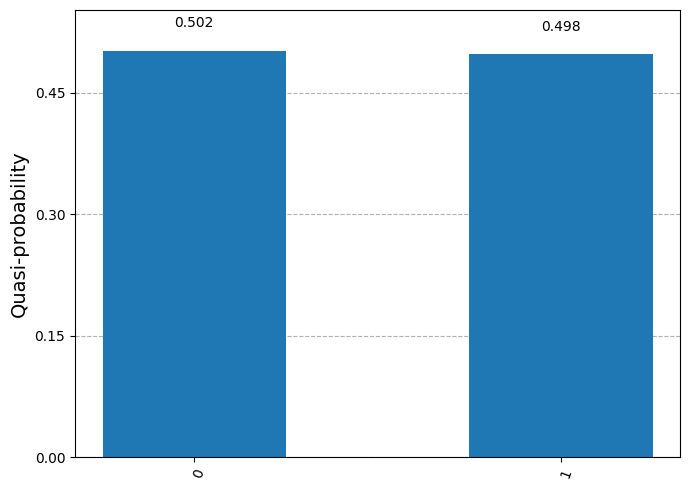

```python
backend = Aer.get_backend("qasm_simulator")
shots = 2048
transpiled_qc = transpile(qc, backend, optimization_level=3)
job = backend.run(transpiled_qc, shots=shots)
counts = job.result().get_counts()
plot_distribution(counts)
```

```python
p0, fid, over = calculate_results(counts)
results["State"].append("10")
results["P(0)"].append(p0)
results["Fidelity"].append(fid)
results["Overlap"].append(over)
print(f"P(0): {p0:.5f}, Fidelity: {fid:.5f}, Overlap: {over:.5f}")
```

```
P(0): 0.50195, Fidelity: 0.00391, Overlap: 0.06250
```

## Task 2 - Results

```python
df_results = display_lab_results(results)
df_results
```

[output not shown]

## Conclusions

In conclusion, the implementation of the SWAP test successfully enabled the calculation of fidelity and overlap for the assigned quantum patterns, validating the theoretical relationship F=2P(0)−1. The results, compiled across 16 different cases, illustrate how specific gate configurations - such as those creating superposition or phase shifts - impact the measurable distance between states. This laboratory exercise highlights the efficiency of quantum state comparison compared to classical methods and serves as a foundational step toward building more complex quantum-enhanced pattern recognition systems and diagnostic tools in quantum information science.